```python
import pandas as pd
import numpy as np
import math
import seaborn as sns
import matplotlib.pyplot as plt
import scipy
from sklearn.linear_model import LogisticRegression
from sklearn.model_selection import GridSearchCV, train_test_split
from sklearn.metrics import accuracy_score, precision_score, recall_score,f1_score, confusion_matrix, ConfusionMatrixDisplay, classification_report
from sklearn.metrics import roc_auc_score, roc_curve
from imblearn.over_sampling import SMOTENC, SMOTEN
from sklearn.ensemble import RandomForestClassifier
from sklearn.preprocessing import OneHotEncoder
from xgboost import XGBClassifier
```

# Read data

```python
df= pd.read_csv(r"C:\Users\Amith R\OneDrive\Desktop\New folder\application_record.csv")
df
```

|  | ID | CODE_GENDER | FLAG_OWN_CAR | FLAG_OWN_REALTY | CNT_CHILDREN | AMT_INCOME_TOTAL | NAME_INCOME_TYPE | NAME_EDUCATION_TYPE | NAME_FAMILY_STATUS | NAME_HOUSING_TYPE | DAYS_BIRTH | DAYS_EMPLOYED | FLAG_MOBIL | FLAG_WORK_PHONE | FLAG_PHONE | FLAG_EMAIL | OCCUPATION_TYPE | CNT_FAM_MEMBERS |
| --- | --- | --- | --- | --- | --- | --- | --- | --- | --- | --- | --- | --- | --- | --- | --- | --- | --- | --- |
| 0 | 5008804 | M | Y | Y | 0 | 427500.0 | Working | Higher education | Civil marriage | Rented apartment | -12005 | -4542 | 1 | 1 | 0 | 0 | NaN | 2.0 |
| 1 | 5008805 | M | Y | Y | 0 | 427500.0 | Working | Higher education | Civil marriage | Rented apartment | -12005 | -4542 | 1 | 1 | 0 | 0 | NaN | 2.0 |
| 2 | 5008806 | M | Y | Y | 0 | 112500.0 | Working | Secondary / secondary special | Married | House / apartment | -21474 | -1134 | 1 | 0 | 0 | 0 | Security staff | 2.0 |
| 3 | 5008808 | F | N | Y | 0 | 270000.0 | Commercial associate | Secondary / secondary special | Single / not married | House / apartment | -19110 | -3051 | 1 | 0 | 1 | 1 | Sales staff | 1.0 |
| 4 | 5008809 | F | N | Y | 0 | 270000.0 | Commercial associate | Secondary / secondary special | Single / not married | House / apartment | -19110 | -3051 | 1 | 0 | 1 | 1 | Sales staff | 1.0 |
| ... | ... | ... | ... | ... | ... | ... | ... | ... | ... | ... | ... | ... | ... | ... | ... | ... | ... | ... |
| 438552 | 6840104 | M | N | Y | 0 | 135000.0 | Pensioner | Secondary / secondary special | Separated | House / apartment | -22717 | 365243 | 1 | 0 | 0 | 0 | NaN | 1.0 |
| 438553 | 6840222 | F | N | N | 0 | 103500.0 | Working | Secondary / secondary special | Single / not married | House / apartment | -15939 | -3007 | 1 | 0 | 0 | 0 | Laborers | 1.0 |
| 438554 | 6841878 | F | N | N | 0 | 54000.0 | Commercial associate | Higher education | Single / not married | With parents | -8169 | -372 | 1 | 1 | 0 | 0 | Sales staff | 1.0 |
| 438555 | 6842765 | F | N | Y | 0 | 72000.0 | Pensioner | Secondary / secondary special | Married | House / apartment | -21673 | 365243 | 1 | 0 | 0 | 0 | NaN | 2.0 |
| 438556 | 6842885 | F | N | Y | 0 | 121500.0 | Working | Secondary / secondary special | Married | House / apartment | -18858 | -1201 | 1 | 0 | 1 | 0 | Sales staff | 2.0 |

438557 rows × 18 columns

```python
df_credit = pd.read_csv(r"C:\Users\Amith R\OneDrive\Desktop\New folder\credit_record.csv")
df_credit
```

|  | ID | MONTHS_BALANCE | STATUS |
| --- | --- | --- | --- |
| 0 | 5001711 | 0 | X |
| 1 | 5001711 | -1 | 0 |
| 2 | 5001711 | -2 | 0 |
| 3 | 5001711 | -3 | 0 |
| 4 | 5001712 | 0 | C |
| ... | ... | ... | ... |
| 1048570 | 5150487 | -25 | C |
| 1048571 | 5150487 | -26 | C |
| 1048572 | 5150487 | -27 | C |
| 1048573 | 5150487 | -28 | C |
| 1048574 | 5150487 | -29 | C |

1048575 rows × 3 columns

# Usable data

We have 2 tables, the first one contains information of each customer,

and the second record the payment behavior.

```python
print('For the first table, number of unique customer ID',df['ID'].nunique())
print('For the second table, number of unique customer ID',df_credit['ID'].nunique())
print('Number of unique customer ID that appearing in both tables:',df[df['ID'].isin(df_credit['ID'])]['ID'].nunique())
```

```
For the first table, number of unique customer ID 438510
For the second table, number of unique customer ID 45985
Number of unique customer ID that appearing in both tables: 36457
```

Only 36457 curtomers are on both table. Hence the maximum usable data to train the model is 36457 samples.

```python
# Filter only usable sample
df = df[df['ID'].isin(df_credit['ID'])]
df_credit = df_credit[df_credit['ID'].isin(df['ID'])]
```

```python
df
```

|  | ID | CODE_GENDER | FLAG_OWN_CAR | FLAG_OWN_REALTY | CNT_CHILDREN | AMT_INCOME_TOTAL | NAME_INCOME_TYPE | NAME_EDUCATION_TYPE | NAME_FAMILY_STATUS | NAME_HOUSING_TYPE | DAYS_BIRTH | DAYS_EMPLOYED | FLAG_MOBIL | FLAG_WORK_PHONE | FLAG_PHONE | FLAG_EMAIL | OCCUPATION_TYPE | CNT_FAM_MEMBERS |
| --- | --- | --- | --- | --- | --- | --- | --- | --- | --- | --- | --- | --- | --- | --- | --- | --- | --- | --- |
| 0 | 5008804 | M | Y | Y | 0 | 427500.0 | Working | Higher education | Civil marriage | Rented apartment | -12005 | -4542 | 1 | 1 | 0 | 0 | NaN | 2.0 |
| 1 | 5008805 | M | Y | Y | 0 | 427500.0 | Working | Higher education | Civil marriage | Rented apartment | -12005 | -4542 | 1 | 1 | 0 | 0 | NaN | 2.0 |
| 2 | 5008806 | M | Y | Y | 0 | 112500.0 | Working | Secondary / secondary special | Married | House / apartment | -21474 | -1134 | 1 | 0 | 0 | 0 | Security staff | 2.0 |
| 3 | 5008808 | F | N | Y | 0 | 270000.0 | Commercial associate | Secondary / secondary special | Single / not married | House / apartment | -19110 | -3051 | 1 | 0 | 1 | 1 | Sales staff | 1.0 |
| 4 | 5008809 | F | N | Y | 0 | 270000.0 | Commercial associate | Secondary / secondary special | Single / not married | House / apartment | -19110 | -3051 | 1 | 0 | 1 | 1 | Sales staff | 1.0 |
| ... | ... | ... | ... | ... | ... | ... | ... | ... | ... | ... | ... | ... | ... | ... | ... | ... | ... | ... |
| 434808 | 5149828 | M | Y | Y | 0 | 315000.0 | Working | Secondary / secondary special | Married | House / apartment | -17348 | -2420 | 1 | 0 | 0 | 0 | Managers | 2.0 |
| 434809 | 5149834 | F | N | Y | 0 | 157500.0 | Commercial associate | Higher education | Married | House / apartment | -12387 | -1325 | 1 | 0 | 1 | 1 | Medicine staff | 2.0 |
| 434810 | 5149838 | F | N | Y | 0 | 157500.0 | Pensioner | Higher education | Married | House / apartment | -12387 | -1325 | 1 | 0 | 1 | 1 | Medicine staff | 2.0 |
| 434811 | 5150049 | F | N | Y | 0 | 283500.0 | Working | Secondary / secondary special | Married | House / apartment | -17958 | -655 | 1 | 0 | 0 | 0 | Sales staff | 2.0 |
| 434812 | 5150337 | M | N | Y | 0 | 112500.0 | Working | Secondary / secondary special | Single / not married | Rented apartment | -9188 | -1193 | 1 | 0 | 0 | 0 | Laborers | 1.0 |

36457 rows × 18 columns

## Label good/bad customers

As the data only provide the credit record (status), but not the decision on whether we

should approve a credit card, we first set up the criteria.

X: No loan

C: paid off that month (on time)

0: 1-29 days past due

1: 30-59 days past due

2: 60-89 days past due

3: 90-119 days past due

4: 120-149 days past due

5: 150+ days past due

We consider customer who make a payment later than 90 days as bad customer.

We also removed customer with only X status, as those customer never used the credit card and are non-benificial data.

We also removed the indeterminates, which is defined as pasting due less than 90 days (but not on time), as they are not strictly defined as good or bad customer.

We used 12 months window as consideration period, we also remove customer with recording period less than 12 months.

```python
# make label
def label_bad(df):
    if (df["STATUS"]=='3') | (df["STATUS"]=='4') | (df["STATUS"]=='5'): # bad
        return 2
    elif (df["STATUS"]=='X'): # no record
        return -1
    elif (df["STATUS"]=='0') | (df["STATUS"]=='1') | (df["STATUS"]=='2'): # indeterminates
        return 1
    else:
        return 0
```

```python
df_credit["MONTHS_BALANCE"] = -df_credit["MONTHS_BALANCE"]
df_credit = df_credit[df_credit["MONTHS_BALANCE"]<=12]
df_credit["Bad_Customer"] = df_credit.apply(label_bad, axis=1)
```

[output not shown]

```python
df_credit
```

|  | ID | MONTHS_BALANCE | STATUS | Bad_Customer |
| --- | --- | --- | --- | --- |
| 92938 | 5008804 | 0 | C | 0 |
| 92939 | 5008804 | 1 | C | 0 |
| 92940 | 5008804 | 2 | C | 0 |
| 92941 | 5008804 | 3 | C | 0 |
| 92942 | 5008804 | 4 | C | 0 |
| ... | ... | ... | ... | ... |
| 1048553 | 5150487 | 8 | C | 0 |
| 1048554 | 5150487 | 9 | C | 0 |
| 1048555 | 5150487 | 10 | C | 0 |
| 1048556 | 5150487 | 11 | C | 0 |
| 1048557 | 5150487 | 12 | C | 0 |

302398 rows × 4 columns

```python
df_credit_labeled = df_credit[['ID','Bad_Customer',"MONTHS_BALANCE"]].groupby('ID',as_index=False).max()
df_credit_labeled
```

|  | ID | Bad_Customer | MONTHS_BALANCE |
| --- | --- | --- | --- |
| 0 | 5008804 | 0 | 12 |
| 1 | 5008805 | 1 | 12 |
| 2 | 5008806 | 1 | 12 |
| 3 | 5008808 | 1 | 4 |
| 4 | 5008810 | 0 | 12 |
| ... | ... | ... | ... |
| 29746 | 5150482 | 0 | 12 |
| 29747 | 5150483 | -1 | 12 |
| 29748 | 5150484 | 1 | 12 |
| 29749 | 5150485 | 1 | 1 |
| 29750 | 5150487 | 0 | 12 |

29751 rows × 3 columns

```python
# remove customer with only X status (no usage data) (labeled as -1)
df_credit_labeled = df_credit_labeled[df_credit_labeled['Bad_Customer']!=-1]
# remove indeterminates customer (labeled as 1)
df_credit_labeled = df_credit_labeled[df_credit_labeled['Bad_Customer']!=1]
# remove customer with period of record less than 12 month
df_credit_labeled = df_credit_labeled[df_credit_labeled['MONTHS_BALANCE']==12]
# Tag Bad_customer as 1 instead (former = 2)
df_credit_labeled['Bad_Customer'] = (df_credit_labeled['Bad_Customer']/2).apply(np.int32)
df_credit_labeled =  df_credit_labeled.drop('MONTHS_BALANCE', axis=1)
```

```python
# merge
df_labeled = df.merge(df_credit_labeled,on='ID',how='inner')
```

# Observe and clean data

```python
df_labeled
```

|  | ID | CODE_GENDER | FLAG_OWN_CAR | FLAG_OWN_REALTY | CNT_CHILDREN | AMT_INCOME_TOTAL | NAME_INCOME_TYPE | NAME_EDUCATION_TYPE | NAME_FAMILY_STATUS | NAME_HOUSING_TYPE | DAYS_BIRTH | DAYS_EMPLOYED | FLAG_MOBIL | FLAG_WORK_PHONE | FLAG_PHONE | FLAG_EMAIL | OCCUPATION_TYPE | CNT_FAM_MEMBERS | Bad_Customer |
| --- | --- | --- | --- | --- | --- | --- | --- | --- | --- | --- | --- | --- | --- | --- | --- | --- | --- | --- | --- |
| 0 | 5008804 | M | Y | Y | 0 | 427500.0 | Working | Higher education | Civil marriage | Rented apartment | -12005 | -4542 | 1 | 1 | 0 | 0 | NaN | 2.0 | 0 |
| 1 | 5008810 | F | N | Y | 0 | 270000.0 | Commercial associate | Secondary / secondary special | Single / not married | House / apartment | -19110 | -3051 | 1 | 0 | 1 | 1 | Sales staff | 1.0 | 0 |
| 2 | 5008811 | F | N | Y | 0 | 270000.0 | Commercial associate | Secondary / secondary special | Single / not married | House / apartment | -19110 | -3051 | 1 | 0 | 1 | 1 | Sales staff | 1.0 | 0 |
| 3 | 5008826 | F | Y | N | 0 | 130500.0 | Working | Incomplete higher | Married | House / apartment | -10669 | -1103 | 1 | 0 | 0 | 0 | Accountants | 2.0 | 0 |
| 4 | 5008830 | F | N | Y | 0 | 157500.0 | Working | Secondary / secondary special | Married | House / apartment | -10031 | -1469 | 1 | 0 | 1 | 0 | Laborers | 2.0 | 0 |
| ... | ... | ... | ... | ... | ... | ... | ... | ... | ... | ... | ... | ... | ... | ... | ... | ... | ... | ... | ... |
| 10255 | 5149056 | F | N | Y | 0 | 112500.0 | Commercial associate | Secondary / secondary special | Married | House / apartment | -15837 | -2694 | 1 | 1 | 1 | 0 | NaN | 2.0 | 0 |
| 10256 | 5149145 | M | Y | Y | 0 | 247500.0 | Working | Secondary / secondary special | Married | House / apartment | -10952 | -3577 | 1 | 1 | 0 | 0 | Laborers | 2.0 | 0 |
| 10257 | 5149158 | M | Y | Y | 0 | 247500.0 | Working | Secondary / secondary special | Married | House / apartment | -10952 | -3577 | 1 | 1 | 0 | 0 | Laborers | 2.0 | 0 |
| 10258 | 5149834 | F | N | Y | 0 | 157500.0 | Commercial associate | Higher education | Married | House / apartment | -12387 | -1325 | 1 | 0 | 1 | 1 | Medicine staff | 2.0 | 1 |
| 10259 | 5149838 | F | N | Y | 0 | 157500.0 | Pensioner | Higher education | Married | House / apartment | -12387 | -1325 | 1 | 0 | 1 | 1 | Medicine staff | 2.0 | 0 |

10260 rows × 19 columns

There are many information that duplicated, but have different ID. These may come from multiple credit cards per user.`

```python
df_labeled = df_labeled.drop('ID',axis=1)
```

```python
# Check whether multiple cards holder are labeled with bad/good or mixing
print('Amount of duplicated data with bad customer labeling: ', df_labeled.duplicated().sum())
print('Amount of duplicated data without bad customer labeling: ', df_labeled.drop('Bad_Customer',axis=1).duplicated().sum())
```

```
Amount of duplicated data with bad customer labeling:  5271
Amount of duplicated data without bad customer labeling:  5313
```

Since the amounts above are not equal, there are customer who are labeled as good and bad customer on different ID. We consider these customers as bad customers (have at least 1 labeled as bad customer).

```python
# Flag duplicate information that come from the same customer
df_labeled['ID_same_customer'] = df_labeled.groupby(['CODE_GENDER', 'FLAG_OWN_CAR', 'FLAG_OWN_REALTY', 'CNT_CHILDREN',
       'AMT_INCOME_TOTAL', 'NAME_INCOME_TYPE', 'NAME_EDUCATION_TYPE',
       'NAME_FAMILY_STATUS', 'NAME_HOUSING_TYPE', 'DAYS_BIRTH',
       'DAYS_EMPLOYED', 'FLAG_MOBIL', 'FLAG_WORK_PHONE', 'FLAG_PHONE',
       'FLAG_EMAIL', 'OCCUPATION_TYPE', 'CNT_FAM_MEMBERS'], dropna=False).ngroup()
```

```python
# Combine information to be just 1 for each customer. Bad_customer tag is 1 if one or more ID is tagged as bad_customer
df_labeled = df_labeled.groupby(['ID_same_customer','CODE_GENDER', 'FLAG_OWN_CAR', 'FLAG_OWN_REALTY', 'CNT_CHILDREN',
       'AMT_INCOME_TOTAL', 'NAME_INCOME_TYPE', 'NAME_EDUCATION_TYPE',
       'NAME_FAMILY_STATUS', 'NAME_HOUSING_TYPE', 'DAYS_BIRTH',
       'DAYS_EMPLOYED', 'FLAG_MOBIL', 'FLAG_WORK_PHONE', 'FLAG_PHONE',
       'FLAG_EMAIL', 'OCCUPATION_TYPE', 'CNT_FAM_MEMBERS'],as_index=False,dropna=False).max()
```

```python
# Recheck for the duplicaite information
df_labeled.drop('ID_same_customer',axis=1).duplicated().sum()
```

```
0
```

# Check for missing data

```python
df_labeled.isna().sum()/df.shape[0]*100
```

```
ID_same_customer       0.000000
CODE_GENDER            0.000000
FLAG_OWN_CAR           0.000000
FLAG_OWN_REALTY        0.000000
CNT_CHILDREN           0.000000
AMT_INCOME_TOTAL       0.000000
NAME_INCOME_TYPE       0.000000
NAME_EDUCATION_TYPE    0.000000
NAME_FAMILY_STATUS     0.000000
NAME_HOUSING_TYPE      0.000000
DAYS_BIRTH             0.000000
DAYS_EMPLOYED          0.000000
FLAG_MOBIL             0.000000
FLAG_WORK_PHONE        0.000000
FLAG_PHONE             0.000000
FLAG_EMAIL             0.000000
OCCUPATION_TYPE        4.226897
CNT_FAM_MEMBERS        0.000000
Bad_Customer           0.000000
dtype: float64
```

About 4.2 % of occupation information is missing, which is a significant amount.

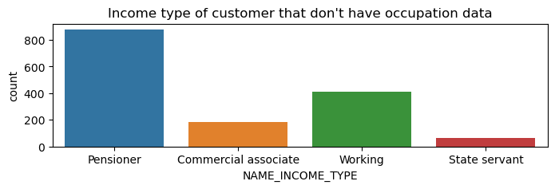

```python
plt.figure(figsize=(8,2))
sns.countplot(x= df_labeled[df_labeled["OCCUPATION_TYPE"].isna()]["NAME_INCOME_TYPE"])
plt.title("Income type of customer that don't have occupation data")
```

From the plot, most of the missing occupation data are pensioner which is make sense. We labeled occupation types of Pensioner as "Pensioner".

```python
# label pensioner occupation type
df_labeled.loc[df_labeled["NAME_INCOME_TYPE"]=="Pensioner","OCCUPATION_TYPE"] = "Pensioner"
```

```python
# Check missing data after assigning pensioner
df_labeled.isna().sum()/df.shape[0]*100
```

```
ID_same_customer       0.000000
CODE_GENDER            0.000000
FLAG_OWN_CAR           0.000000
FLAG_OWN_REALTY        0.000000
CNT_CHILDREN           0.000000
AMT_INCOME_TOTAL       0.000000
NAME_INCOME_TYPE       0.000000
NAME_EDUCATION_TYPE    0.000000
NAME_FAMILY_STATUS     0.000000
NAME_HOUSING_TYPE      0.000000
DAYS_BIRTH             0.000000
DAYS_EMPLOYED          0.000000
FLAG_MOBIL             0.000000
FLAG_WORK_PHONE        0.000000
FLAG_PHONE             0.000000
FLAG_EMAIL             0.000000
OCCUPATION_TYPE        1.818581
CNT_FAM_MEMBERS        0.000000
Bad_Customer           0.000000
dtype: float64
```

About 1.8 % of occupation information is missing.

We decided to remove these data.

```python
# drop null occupation rows
df_labeled = df_labeled.dropna(axis=0)
df_labeled.isna().sum()/df.shape[0]*100
```

```
ID_same_customer       0.0
CODE_GENDER            0.0
FLAG_OWN_CAR           0.0
FLAG_OWN_REALTY        0.0
CNT_CHILDREN           0.0
AMT_INCOME_TOTAL       0.0
NAME_INCOME_TYPE       0.0
NAME_EDUCATION_TYPE    0.0
NAME_FAMILY_STATUS     0.0
NAME_HOUSING_TYPE      0.0
DAYS_BIRTH             0.0
DAYS_EMPLOYED          0.0
FLAG_MOBIL             0.0
FLAG_WORK_PHONE        0.0
FLAG_PHONE             0.0
FLAG_EMAIL             0.0
OCCUPATION_TYPE        0.0
CNT_FAM_MEMBERS        0.0
Bad_Customer           0.0
dtype: float64
```

## Check for mis-spelling of categorical columns

```python
df_labeled["CODE_GENDER"].unique()
```

```
array(['F', 'M'], dtype=object)
```

```python
df_labeled["FLAG_OWN_CAR"].unique()
```

```
array(['N', 'Y'], dtype=object)
```

```python
df_labeled["FLAG_OWN_REALTY"].unique()
```

```
array(['N', 'Y'], dtype=object)
```

```python
df_labeled["NAME_INCOME_TYPE"].unique()
```

```
array(['Working', 'Pensioner', 'State servant', 'Commercial associate',
       'Student'], dtype=object)
```

```python
df_labeled["NAME_FAMILY_STATUS"].unique()
```

```
array(['Civil marriage', 'Married', 'Single / not married', 'Widow',
       'Separated'], dtype=object)
```

```python
df_labeled["NAME_HOUSING_TYPE"].unique()
```

```
array(['House / apartment', 'Office apartment', 'With parents',
       'Municipal apartment', 'Co-op apartment', 'Rented apartment'],
      dtype=object)
```

```python
df_labeled["OCCUPATION_TYPE"].unique()
```

```
array(['Managers', 'Pensioner', 'Core staff', 'Accountants',
       'Sales staff', 'Cleaning staff', 'Medicine staff', 'Laborers',
       'Security staff', 'High skill tech staff', 'Cooking staff',
       'Private service staff', 'Waiters/barmen staff', 'Secretaries',
       'HR staff', 'Low-skill Laborers', 'Drivers', 'IT staff',
       'Realty agents'], dtype=object)
```

All of the categorical data look good. There is no mis-spelling and repeated type.

## Remove sensitive data

Here we remove gender out of considering data as it is a sensitive judement.

```python
# drop gender
df_labeled = df_labeled.drop("CODE_GENDER", axis=1)
```

```python
df_labeled.head()
```

|  | ID_same_customer | FLAG_OWN_CAR | FLAG_OWN_REALTY | CNT_CHILDREN | AMT_INCOME_TOTAL | NAME_INCOME_TYPE | NAME_EDUCATION_TYPE | NAME_FAMILY_STATUS | NAME_HOUSING_TYPE | DAYS_BIRTH | DAYS_EMPLOYED | FLAG_MOBIL | FLAG_WORK_PHONE | FLAG_PHONE | FLAG_EMAIL | OCCUPATION_TYPE | CNT_FAM_MEMBERS | Bad_Customer |
| --- | --- | --- | --- | --- | --- | --- | --- | --- | --- | --- | --- | --- | --- | --- | --- | --- | --- | --- |
| 0 | 0 | N | N | 0 | 27000.0 | Working | Higher education | Civil marriage | House / apartment | -14869 | -5067 | 1 | 1 | 0 | 0 | Managers | 2.0 | 0 |
| 1 | 1 | N | N | 0 | 33300.0 | Pensioner | Secondary / secondary special | Married | Office apartment | -19605 | 365243 | 1 | 0 | 0 | 0 | Pensioner | 2.0 | 0 |
| 2 | 2 | N | N | 0 | 36000.0 | Working | Secondary / secondary special | Married | With parents | -14500 | -459 | 1 | 1 | 0 | 0 | Core staff | 2.0 | 0 |
| 3 | 3 | N | N | 0 | 36900.0 | Pensioner | Higher education | Married | House / apartment | -22581 | 365243 | 1 | 0 | 0 | 0 | Pensioner | 2.0 | 0 |
| 4 | 4 | N | N | 0 | 40500.0 | Pensioner | Secondary / secondary special | Single / not married | House / apartment | -21091 | 365243 | 1 | 0 | 0 | 0 | Pensioner | 1.0 | 0 |

# Exploratory data analysis (EDA) and Features engineering

## Set DAYS_BIRTH, DAYS_EMPLOTED to a more appropriate format

Both parameter are recorded as amount of date back in time.

```python
# Adjust DAYS_BIRTH to AGE in year
df_labeled["AGE"] = ((-df_labeled["DAYS_BIRTH"])/365).apply(int)
df_labeled = df_labeled.drop(["DAYS_BIRTH"],axis=1)
```

```python
# Adjust DAYS_EMPLOYED to YEAR_EMPLOYED in year
df_labeled["YEAR_EMPLOYED"] = np.ceil(-(df_labeled["DAYS_EMPLOYED"]/365))
df_labeled = df_labeled.drop(["DAYS_EMPLOYED"],axis=1)
```

```python
df_labeled = df_labeled.reset_index(drop=True)
df_labeled = df_labeled.drop(["ID_same_customer"],axis=1)
```

```python
df_labeled.head()
```

|  | FLAG_OWN_CAR | FLAG_OWN_REALTY | CNT_CHILDREN | AMT_INCOME_TOTAL | NAME_INCOME_TYPE | NAME_EDUCATION_TYPE | NAME_FAMILY_STATUS | NAME_HOUSING_TYPE | FLAG_MOBIL | FLAG_WORK_PHONE | FLAG_PHONE | FLAG_EMAIL | OCCUPATION_TYPE | CNT_FAM_MEMBERS | Bad_Customer | AGE | YEAR_EMPLOYED |
| --- | --- | --- | --- | --- | --- | --- | --- | --- | --- | --- | --- | --- | --- | --- | --- | --- | --- |
| 0 | N | N | 0 | 27000.0 | Working | Higher education | Civil marriage | House / apartment | 1 | 1 | 0 | 0 | Managers | 2.0 | 0 | 40 | 14.0 |
| 1 | N | N | 0 | 33300.0 | Pensioner | Secondary / secondary special | Married | Office apartment | 1 | 0 | 0 | 0 | Pensioner | 2.0 | 0 | 53 | -1000.0 |
| 2 | N | N | 0 | 36000.0 | Working | Secondary / secondary special | Married | With parents | 1 | 1 | 0 | 0 | Core staff | 2.0 | 0 | 39 | 2.0 |
| 3 | N | N | 0 | 36900.0 | Pensioner | Higher education | Married | House / apartment | 1 | 0 | 0 | 0 | Pensioner | 2.0 | 0 | 61 | -1000.0 |
| 4 | N | N | 0 | 40500.0 | Pensioner | Secondary / secondary special | Single / not married | House / apartment | 1 | 0 | 0 | 0 | Pensioner | 1.0 | 0 | 57 | -1000.0 |

## FLAG_MOBIL, FLAG_WORK_PHONE, FLAG_PHONE, FLAG_EMAIL, FLAG_OWN_CAR, and FLAG_OWN_REALTY

### FLAG_MOBIL (Is there a mobile phone) is 1 for all row, which is not a beneficial data.

```python
# Drop old flag
df_labeled = df_labeled.drop(["FLAG_WORK_PHONE","FLAG_EMAIL","FLAG_PHONE"],axis=1)
```

```python
df_labeled = df_labeled.drop(["FLAG_MOBIL"],axis=1)
```

```python
# Drop FLAG_OWN_CAR and FLAG_OWN_REALTY
df_labeled = df_labeled.drop(["FLAG_OWN_CAR","FLAG_OWN_REALTY"],axis=1)
```

## NAME_INCOME_TYPE (Type of income)

```python
# Percentage of sample of each income type
df_labeled["NAME_INCOME_TYPE"].value_counts(normalize=True)*100
```

```
Working                 48.646125
Commercial associate    22.992530
Pensioner               20.728291
State servant            7.609711
Student                  0.023343
Name: NAME_INCOME_TYPE, dtype: float64
```

Student frequency is too small, and we cannot re-categorize it to other group. We decided to drop it.

```python
df_labeled = df_labeled[df_labeled["NAME_INCOME_TYPE"]!="Student"]
df_labeled["NAME_INCOME_TYPE"].value_counts(normalize=True)*100
```

```
Working                 48.657483
Commercial associate    22.997899
Pensioner               20.733131
State servant            7.611487
Name: NAME_INCOME_TYPE, dtype: float64
```

## NAME_EDUCATION_TYPE (Type of education)

```python
# Percentage of sample of each education type
df_labeled["NAME_EDUCATION_TYPE"].value_counts(normalize=True)*100
```

```
Secondary / secondary special    70.044361
Higher education                 25.449451
Incomplete higher                 3.105300
Lower secondary                   1.354191
Academic degree                   0.046696
Name: NAME_EDUCATION_TYPE, dtype: float64
```

```python
df_labeled["NAME_EDUCATION_TYPE"] = df_labeled["NAME_EDUCATION_TYPE"].replace({"Academic degree":"Higher education","Lower secondary":"Secondary/Lower","Secondary / secondary special":"Secondary/Lower"})
df_labeled["NAME_EDUCATION_TYPE"].value_counts(normalize=True)*100
```

```
Secondary/Lower      71.398552
Higher education     25.496148
Incomplete higher     3.105300
Name: NAME_EDUCATION_TYPE, dtype: float64
```

```python
df_labeled = df_labeled.drop("NAME_EDUCATION_TYPE", axis=1)
```

## NAME_FAMILY_STATUS

```python
df_labeled["NAME_FAMILY_STATUS"].value_counts(normalize=True)*100
```

```
Married                 68.876955
Single / not married    12.748074
Civil marriage           8.311931
Separated                5.603549
Widow                    4.459491
Name: NAME_FAMILY_STATUS, dtype: float64
```

```python
df_labeled["NAME_FAMILY_STATUS"] = df_labeled["NAME_FAMILY_STATUS"].replace({"Widow":"Separated/Widow","Separated":"Separated/Widow"})
df_labeled["NAME_FAMILY_STATUS"].value_counts(normalize=True)*100
```

```
Married                 68.876955
Single / not married    12.748074
Separated/Widow         10.063040
Civil marriage           8.311931
Name: NAME_FAMILY_STATUS, dtype: float64
```

## NAME_HOUSING_TYPE

```python
df_labeled["NAME_HOUSING_TYPE"].value_counts(normalize=True)*100
```

```
House / apartment      89.633435
With parents            4.342750
Municipal apartment     3.478870
Rented apartment        1.260799
Office apartment        0.863880
Co-op apartment         0.420266
Name: NAME_HOUSING_TYPE, dtype: float64
```

```python
df_labeled["NAME_HOUSING_TYPE"] = df_labeled["NAME_HOUSING_TYPE"].replace({"Co-op apartment":"House / apartment","Office apartment":"House / apartment"})
df_labeled["NAME_HOUSING_TYPE"].value_counts(normalize=True)*100
```

```
House / apartment      90.917581
With parents            4.342750
Municipal apartment     3.478870
Rented apartment        1.260799
Name: NAME_HOUSING_TYPE, dtype: float64
```

```python
# Drop NAME_HOUSING_TYPE
df_labeled = df_labeled.drop("NAME_HOUSING_TYPE", axis=1)
```

## OCCUPATION_TYPE

```python
df_labeled["OCCUPATION_TYPE"].value_counts(normalize=True)*100
```

```
Pensioner                20.733131
Laborers                 20.429605
Sales staff              10.506654
Core staff               10.389914
Managers                  9.502685
Drivers                   7.658184
High skill tech staff     4.482839
Accountants               3.689003
Medicine staff            3.572262
Security staff            2.077983
Cooking staff             1.937894
Cleaning staff            1.751109
Private service staff     0.887229
Low-skill Laborers        0.723792
Secretaries               0.583703
Waiters/barmen staff      0.490311
HR staff                  0.256829
IT staff                  0.186785
Realty agents             0.140089
Name: OCCUPATION_TYPE, dtype: float64
```

```python
df_labeled = df_labeled[~df_labeled["OCCUPATION_TYPE"].isin(["Private service staff","Low-skill Laborers","Secretaries",
                                                             "Waiters/barmen staff","HR staff","IT staff","Realty agents"])]
```

```python
# GROUP BY
df_labeled['OCCUPATION_TYPE'] = df_labeled['OCCUPATION_TYPE'].replace({"Security staff":"G1"})
df_labeled['OCCUPATION_TYPE'] = df_labeled['OCCUPATION_TYPE'].replace({"High skill tech staff":"G2"})
df_labeled['OCCUPATION_TYPE'] = df_labeled['OCCUPATION_TYPE'].replace({"Cleaning staff":"G3","Medicine staff":"G3"})
df_labeled['OCCUPATION_TYPE'] = df_labeled['OCCUPATION_TYPE'].replace({"Pensioner":"G4","Cooking staff":"G4"})
df_labeled['OCCUPATION_TYPE'] = df_labeled['OCCUPATION_TYPE'].replace({"Managers":"G5","Laborers":"G5","Core staff":"G5"})
df_labeled['OCCUPATION_TYPE'] = df_labeled['OCCUPATION_TYPE'].replace({"Drivers":"G6"})
df_labeled['OCCUPATION_TYPE'] = df_labeled['OCCUPATION_TYPE'].replace({"Accountants":"G7"})
df_labeled['OCCUPATION_TYPE'] = df_labeled['OCCUPATION_TYPE'].replace({"Sales staff":"G8"})

df_labeled['OCCUPATION_TYPE'].value_counts(normalize=True)*100
```

```
G5    41.684769
G4    23.437123
G8    10.861694
G6     7.916968
G3     5.503259
G2     4.634323
G7     3.813662
G1     2.148202
Name: OCCUPATION_TYPE, dtype: float64
```

## CNT_CHILDREN (Number of children) and CNT_FAM_MEMBERS (Number of family member)

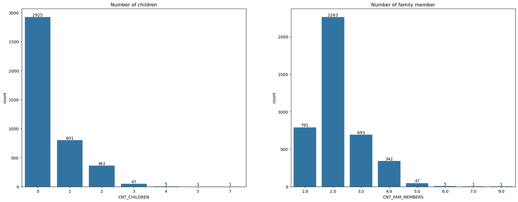

```python
fig, ax = plt.subplots(1, 2, figsize = (22,8))
cplot = sns.countplot(data=df_labeled, x="CNT_CHILDREN", ax=ax[0],color='tab:Blue')
for container in cplot.containers:
    cplot.bar_label(container)
ax[0].set_title('Number of children')

cplot = sns.countplot(data=df_labeled, x="CNT_FAM_MEMBERS", ax=ax[1],color='tab:Blue')
for container in cplot.containers:
    cplot.bar_label(container)
ax[1].set_title('Number of family member')
```

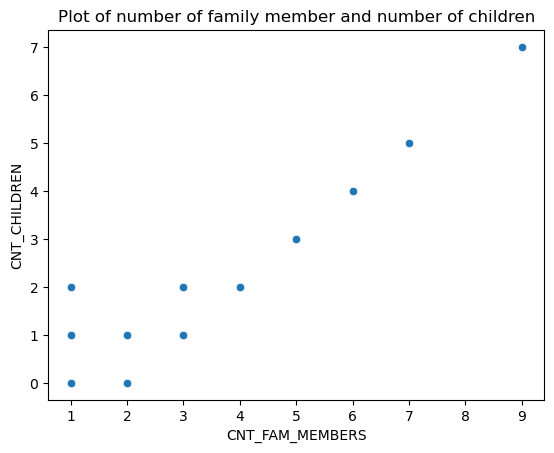

```python
sns.scatterplot(data=df_labeled, x="CNT_FAM_MEMBERS",y="CNT_CHILDREN")
plt.title('Plot of number of family member and number of children')
```

```python
df_labeled[["CNT_CHILDREN","CNT_FAM_MEMBERS"]].corr()
```

|  | CNT_CHILDREN | CNT_FAM_MEMBERS |
| --- | --- | --- |
| CNT_CHILDREN | 1.000000 | 0.882908 |
| CNT_FAM_MEMBERS | 0.882908 | 1.000000 |

The plot of number of family member and number of children and correlation table confirm the correlation. As the number of family member cover the number of children, we chose to drop the number of children feature.

```python
df_labeled = df_labeled.drop("CNT_CHILDREN",axis=1)
```

```python
df_labeled["CNT_FAM_MEMBERS"].value_counts(normalize=True)*100
```

```
2.0    54.622254
1.0    19.092445
3.0    16.727009
4.0     8.254888
5.0     1.134444
6.0     0.120685
9.0     0.024137
7.0     0.024137
Name: CNT_FAM_MEMBERS, dtype: float64
```

```python
def gen_bin_fam(df):
    # return group assigned for bin size = binSize
    # assign data > binOver to the last group
    binSize = 1
    binOver = 5
    if df < binOver:
        return str(math.ceil(df/binSize))
    else:
        return str(math.ceil(binOver/binSize))
```

```python
df_labeled["FAM_GROUP"] = df_labeled["CNT_FAM_MEMBERS"].apply(gen_bin_fam)
df_labeled["FAM_GROUP"] = df_labeled["FAM_GROUP"].astype('object')
```

```python
df_labeled= df_labeled.drop("CNT_FAM_MEMBERS",axis=1)
```

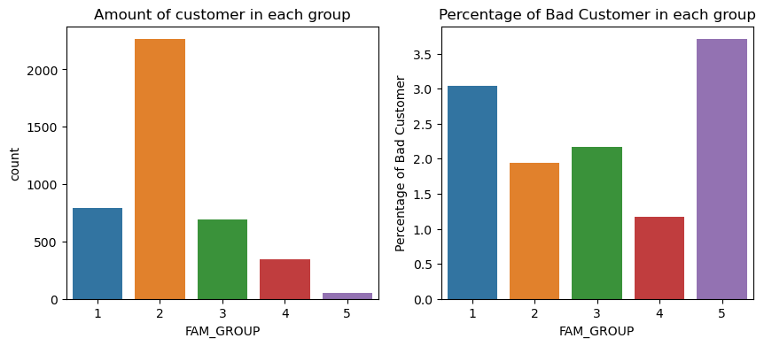

```python
fig, ax = plt.subplots(1, 2, figsize = (10,4))
RowPlot = "FAM_GROUP"
sns.countplot(data=df_labeled, x=RowPlot,ax=ax[0],order=['1','2','3','4','5'])
ax[0].set_title("Amount of customer in each group")

df_fam_percent_bad = df_labeled[[ RowPlot,"Bad_Customer"]].groupby(RowPlot,as_index=False).mean()
df_fam_percent_bad["Bad_Customer"] = df_fam_percent_bad["Bad_Customer"]*100
sns.barplot(data=df_fam_percent_bad, x=RowPlot, y="Bad_Customer", ax=ax[1])
plt.ylabel("Percentage of Bad Customer")
ax[1].set_title("Percentage of Bad Customer in each group")
```

## AGE

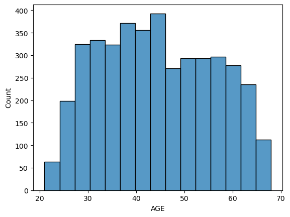

```python
sns.histplot(data=df_labeled, x="AGE",bins=15)
```

```python
def gen_bin_age(df):
    # return group assigned for bin size = binSize
    # assign data > binOver to the last group
    binSize = 5
    binOver = 65
    binMin = 25
    if df <= binMin:
        return str(1)
    elif df <= binOver:
        return str(math.ceil((df-binMin)/binSize))
    else:
        return str(math.ceil((binOver-binMin)/binSize))
```

```python
df_labeled["AGE_GROUP"] = df_labeled["AGE"].apply(gen_bin_age)
df_labeled["AGE_GROUP"] = df_labeled["AGE_GROUP"].astype('object')
```

```python
df_labeled= df_labeled.drop("AGE",axis=1)
```

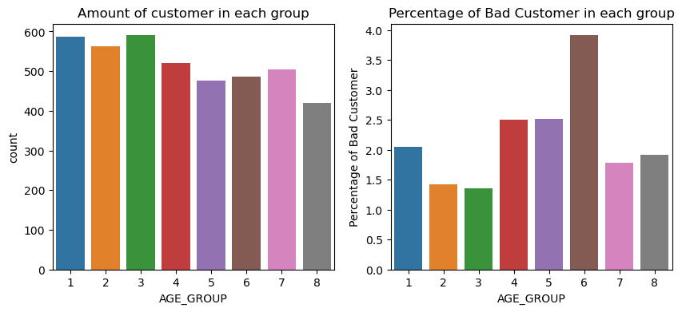

```python
fig, ax = plt.subplots(1, 2, figsize = (10,4))
RowPlot = "AGE_GROUP"
sns.countplot(data=df_labeled, x=RowPlot,ax=ax[0],order=map(str,range(1,9)))
ax[0].set_title("Amount of customer in each group")

df_fam_percent_bad = df_labeled[[ RowPlot,"Bad_Customer"]].groupby(RowPlot,as_index=False).mean()
df_fam_percent_bad["Bad_Customer"] = df_fam_percent_bad["Bad_Customer"]*100
sns.barplot(data=df_fam_percent_bad, x=RowPlot, y="Bad_Customer", ax=ax[1],order=map(str,range(1,9)))
plt.ylabel("Percentage of Bad Customer")
ax[1].set_title("Percentage of Bad Customer in each group")
```

From the graph, customer age between 50-55 (group 6) has high percentage of bad customer.

## AMT_INCOME_TOTAL

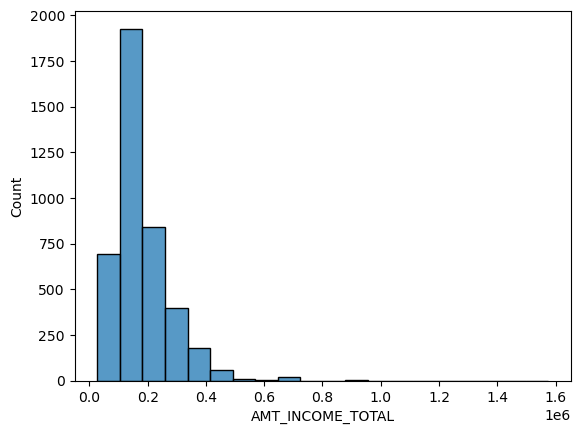

```python
sns.histplot(data=df_labeled, x="AMT_INCOME_TOTAL",bins=20)
```

```python
def gen_bin_income(df):
    # return group assigned for bin size = binSize
    # assign data > binOver to the last group
    binSize =40000
    binOver = 320000
    binMin = 80000
    if df <= binMin:
        return str(1)
    elif df <= binOver:
        return str(math.ceil((df-binMin)/binSize))
    else:
        return str(math.ceil((binOver-binMin)/binSize))
```

```python
df_labeled["AMT_INCOME_TOTAL_GROUP"] = df_labeled["AMT_INCOME_TOTAL"].apply(gen_bin_income)
df_labeled["AMT_INCOME_TOTAL_GROUP"] = df_labeled["AMT_INCOME_TOTAL_GROUP"].astype('object')
df_labeled= df_labeled.drop("AMT_INCOME_TOTAL",axis=1)
```

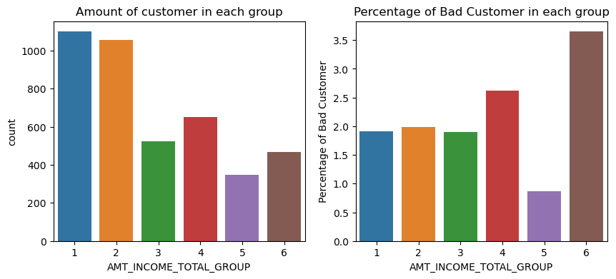

```python
fig, ax = plt.subplots(1, 2, figsize = (10,4))
RowPlot = "AMT_INCOME_TOTAL_GROUP"
sns.countplot(data=df_labeled, x=RowPlot,ax=ax[0],order=['1','2','3','4','5','6'])
ax[0].set_title("Amount of customer in each group")

df_fam_percent_bad = df_labeled[[ RowPlot,"Bad_Customer"]].groupby(RowPlot,as_index=False).mean()
df_fam_percent_bad["Bad_Customer"] = df_fam_percent_bad["Bad_Customer"]*100
sns.barplot(data=df_fam_percent_bad, x=RowPlot, y="Bad_Customer", ax=ax[1])
plt.ylabel("Percentage of Bad Customer")
ax[1].set_title("Percentage of Bad Customer in each group")
```

## YEAR_EMPLOYED

For year employed, we could not continue with continuous data as year employed for pensioner is undefined. Hence we group year employed to be a categorical data.

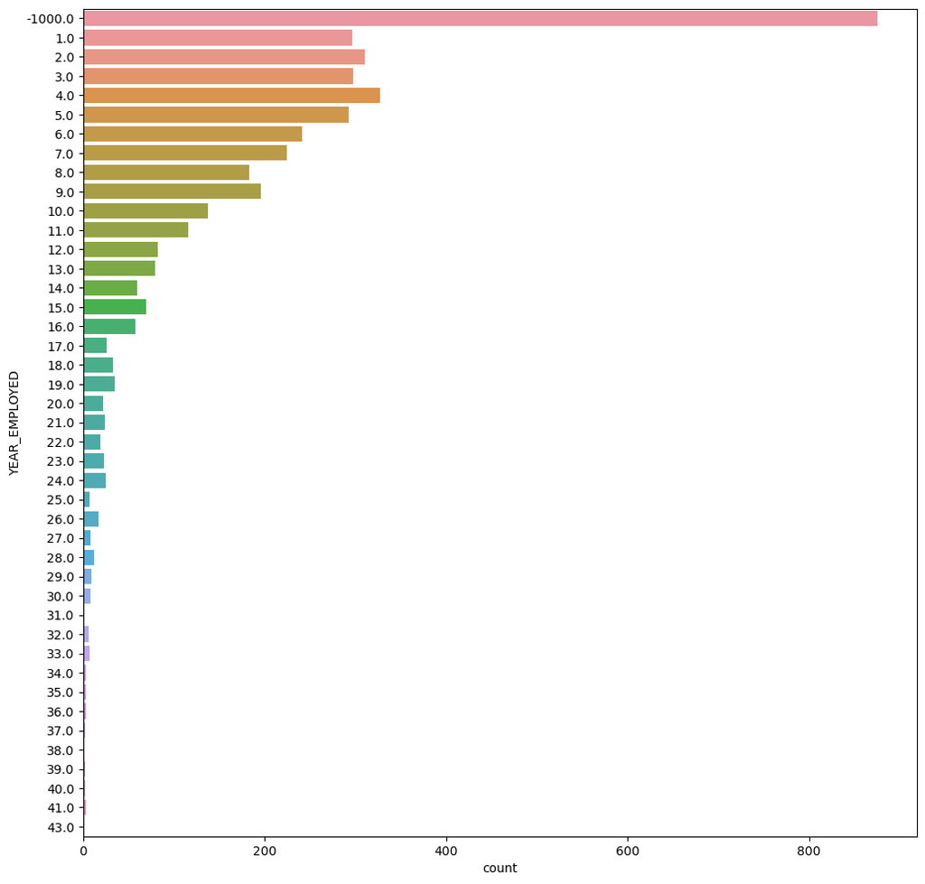

```python
# Show distribution of the data
fig, ax = plt.subplots(figsize=(12, 12))
sns.countplot(data=df_labeled,y="YEAR_EMPLOYED")
```

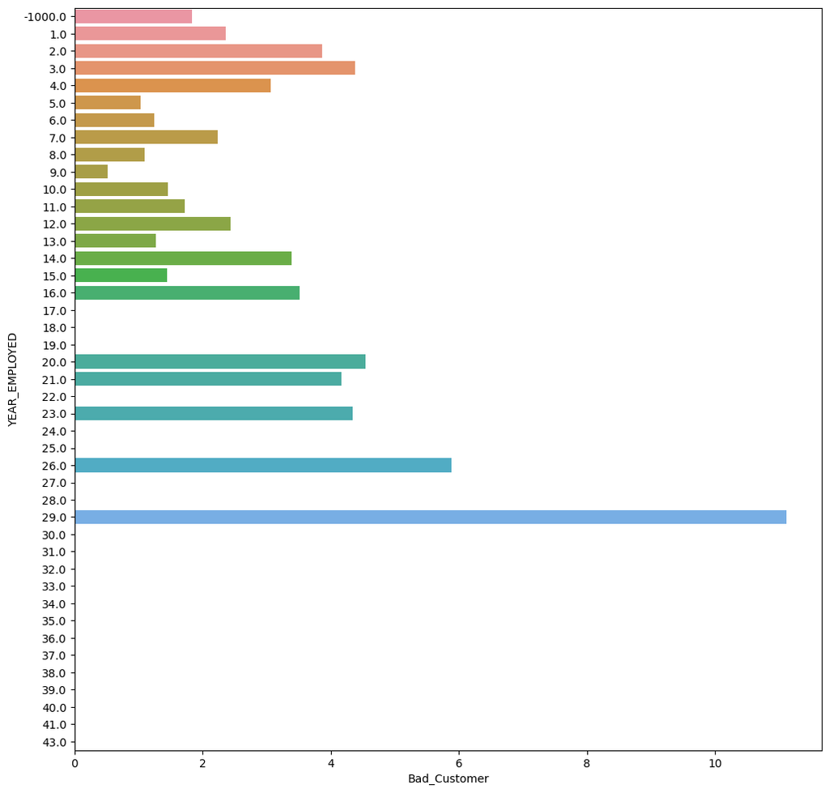

```python
# Percentage of bad customer for each year employed`
fig, ax = plt.subplots(figsize=(12, 12))
df_year_percent_bad = df_labeled[["YEAR_EMPLOYED","Bad_Customer"]].groupby("YEAR_EMPLOYED",as_index=False).mean()
df_year_percent_bad["Bad_Customer"] = df_year_percent_bad["Bad_Customer"]*100
sns.barplot(data=df_year_percent_bad, y="YEAR_EMPLOYED", x="Bad_Customer",orient='h')
```

We categorize this into categorical data instead. For pensioner we separatly grouped them together. We grouped customer have been working greater than 16 years together. For the customers have been working between 2 and 16 we group them with 2 year bin spacing.

```python
def gen_bin_year(df):
    # return group assigned for bin size = binSize
    # assign data > binOver to the last group
    binSize = 2
    binOver = 16
    if df == -1000:
        return str(1)
    elif df <= binOver:
        return str(math.ceil(df/binSize) + 1)
    else:
        return str(math.ceil(binOver/binSize) + 1)
```

```python
df_labeled["YEAR_EMPLOYED_GROUP"] = df_labeled["YEAR_EMPLOYED"].apply(gen_bin_year)
```

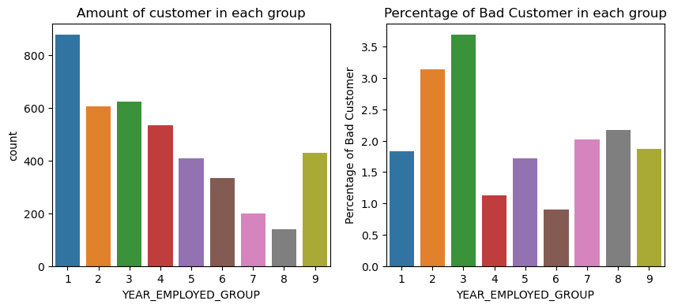

```python
fig, ax = plt.subplots(1, 2, figsize = (10,4))
RowPlot = "YEAR_EMPLOYED_GROUP"
sns.countplot(data=df_labeled, x=RowPlot,ax=ax[0],order=map(str,range(1,10)))
ax[0].set_title("Amount of customer in each group")

df_fam_percent_bad = df_labeled[[ RowPlot,"Bad_Customer"]].groupby(RowPlot,as_index=False).mean()
df_fam_percent_bad["Bad_Customer"] = df_fam_percent_bad["Bad_Customer"]*100
sns.barplot(data=df_fam_percent_bad, x=RowPlot, y="Bad_Customer", ax=ax[1])
plt.ylabel("Percentage of Bad Customer")
ax[1].set_title("Percentage of Bad Customer in each group")
```

```python
df_labeled= df_labeled.drop("YEAR_EMPLOYED",axis=1)
df_labeled["YEAR_EMPLOYED_GROUP"] = df_labeled["YEAR_EMPLOYED_GROUP"].astype('object')
```

# Modeling

```python
df_labeled.head()
```

|  | NAME_INCOME_TYPE | NAME_FAMILY_STATUS | OCCUPATION_TYPE | Bad_Customer | FAM_GROUP | AGE_GROUP | AMT_INCOME_TOTAL_GROUP | YEAR_EMPLOYED_GROUP |
| --- | --- | --- | --- | --- | --- | --- | --- | --- |
| 0 | Working | Civil marriage | G5 | 0 | 2 | 3 | 1 | 8 |
| 1 | Pensioner | Married | G4 | 0 | 2 | 6 | 1 | 1 |
| 2 | Working | Married | G5 | 0 | 2 | 3 | 1 | 2 |
| 3 | Pensioner | Married | G4 | 0 | 2 | 8 | 1 | 1 |
| 4 | Pensioner | Single / not married | G4 | 0 | 1 | 7 | 1 | 1 |

```python
df_labeled["Bad_Customer"].value_counts(normalize=True)*100
```

```
0    97.851798
1     2.148202
Name: Bad_Customer, dtype: float64
```

Split data into train and test set.

Handle imbalance data by using SMOTE.

Encode data

```python
df_LogReg_one = df_labeled
x_LogReg = df_LogReg_one.drop("Bad_Customer",axis=1)
y_LogReg = df_LogReg_one["Bad_Customer"]
x_LogReg_train, x_LogReg_test, y_LogReg_train, y_LogReg_test = train_test_split(x_LogReg, y_LogReg, test_size=0.25, stratify=y_LogReg, random_state=42)
```

```python
x_LogReg_train.info()
```

```
<class 'pandas.core.frame.DataFrame'>
Int64Index: 3107 entries, 2861 to 1167
Data columns (total 7 columns):
 #   Column                  Non-Null Count  Dtype
---  ------                  --------------  -----
 0   NAME_INCOME_TYPE        3107 non-null   object
 1   NAME_FAMILY_STATUS      3107 non-null   object
 2   OCCUPATION_TYPE         3107 non-null   object
 3   FAM_GROUP               3107 non-null   object
 4   AGE_GROUP               3107 non-null   object
 5   AMT_INCOME_TOTAL_GROUP  3107 non-null   object
 6   YEAR_EMPLOYED_GROUP     3107 non-null   object
dtypes: object(7)
memory usage: 194.2+ KB
```

```python
x_train_balance,y_train_balance = SMOTEN(random_state=10).fit_resample(x_LogReg_train,y_LogReg_train)
x_LogReg_train_encoded = pd.get_dummies(x_train_balance)
x_LogReg_test_encoded = pd.get_dummies(x_LogReg_test)
```

```python
x_LogReg_train_encoded.info()
```

```
<class 'pandas.core.frame.DataFrame'>
RangeIndex: 6080 entries, 0 to 6079
Data columns (total 44 columns):
 #   Column                                   Non-Null Count  Dtype
---  ------                                   --------------  -----
 0   NAME_INCOME_TYPE_Commercial associate    6080 non-null   uint8
 1   NAME_INCOME_TYPE_Pensioner               6080 non-null   uint8
 2   NAME_INCOME_TYPE_State servant           6080 non-null   uint8
 3   NAME_INCOME_TYPE_Working                 6080 non-null   uint8
 4   NAME_FAMILY_STATUS_Civil marriage        6080 non-null   uint8
 5   NAME_FAMILY_STATUS_Married               6080 non-null   uint8
 6   NAME_FAMILY_STATUS_Separated/Widow       6080 non-null   uint8
 7   NAME_FAMILY_STATUS_Single / not married  6080 non-null   uint8
 8   OCCUPATION_TYPE_G1                       6080 non-null   uint8
 9   OCCUPATION_TYPE_G2                       6080 non-null   uint8
```

[output cut: 36 more lines]

## Binary Logistic regression

```python
log_clf = LogisticRegression(random_state=42, max_iter=2000).fit(x_LogReg_train_encoded, y_train_balance)
y_predict= log_clf.predict(x_LogReg_test_encoded)
log_cm = confusion_matrix(y_LogReg_test, y_predict, labels=log_clf.classes_)
```

```python
# Create display of confusion matrix
log_disp = ConfusionMatrixDisplay(confusion_matrix=log_cm, display_labels=log_clf.classes_)
```

[output not shown]

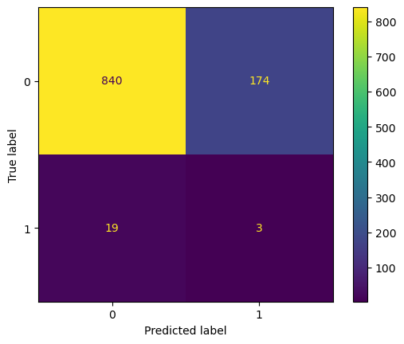

```python
# Plot confusion matrix
log_disp.plot(values_format='')
```

```python
# Display plot
plt.show()
print(classification_report(y_LogReg_test,y_predict))
y_pred_log = y_predict.copy()
```

```
              precision    recall  f1-score   support

           0       0.98      0.83      0.90      1014
           1       0.02      0.14      0.03        22

    accuracy                           0.81      1036
   macro avg       0.50      0.48      0.46      1036
weighted avg       0.96      0.81      0.88      1036
```

## Random Forest

```python
cv_params = {'n_estimators' : [50,100,200],
              'max_depth' : [10,20,50],
              'min_samples_leaf':[1,5,10]}
rf = RandomForestClassifier(random_state=0)
rf_val = GridSearchCV(rf, cv_params, refit='f1')
rf_val.fit(x_LogReg_train_encoded, y_train_balance)
```

```
GridSearchCV(estimator=RandomForestClassifier(random_state=0),
             param_grid={'max_depth': [10, 20, 50],
                         'min_samples_leaf': [1, 5, 10],
                         'n_estimators': [50, 100, 200]},
             refit='f1')
```

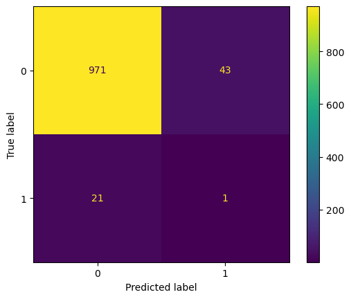

```
              precision    recall  f1-score   support

           0       0.98      0.96      0.97      1014
           1       0.02      0.05      0.03        22

    accuracy                           0.94      1036
   macro avg       0.50      0.50      0.50      1036
weighted avg       0.96      0.94      0.95      1036
```

```python
y_predict = rf_val.predict(x_LogReg_test_encoded)
log_cm = confusion_matrix(y_LogReg_test, y_predict, labels=log_clf.classes_)

# Create display of confusion matrix
log_disp = ConfusionMatrixDisplay(confusion_matrix=log_cm,
                                  display_labels=log_clf.classes_)

# Plot confusion matrix
log_disp.plot(values_format='')

# Display plot
plt.show()
print(classification_report(y_LogReg_test,y_predict))
y_pred_rf = y_predict.copy()
```

# Conclusion

The models developed failed to predict bad customers. Though the process can be finely tuned,the performance of the model is not increase significantlty. The assumption we made are 1) The lack of highly relavant data, e.g. debt, mortgage, and expense. 2) There is small example of bad customer (the data is highly imbalance).